# 102A

Randy Deng

1/20/2020

# 1. Structured Flowchart

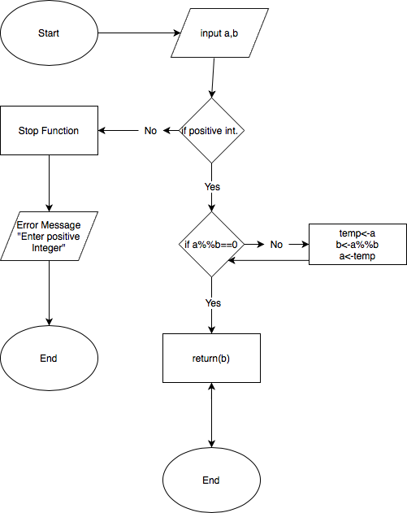

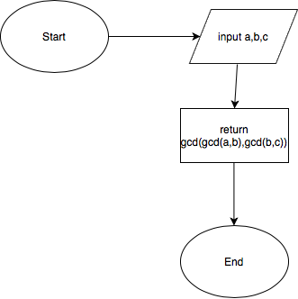

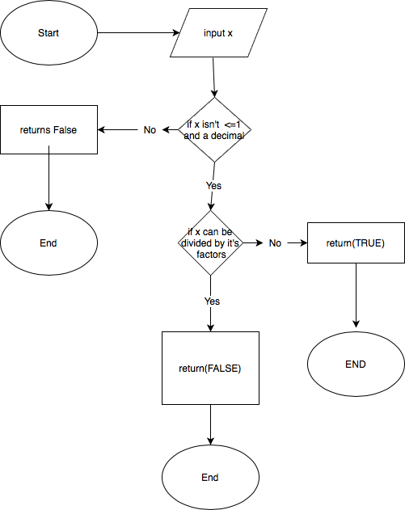

[figure not shown]

# 2. Pseudo-Code

## gcd

I.Make sure inputs are positive integers

- 1.check that inputs are greater than 0
  - a.if statement checking inputs are >= 0
- 2.check that inputs are integers
  - a.if statement to check inputs divided by 1 has a remainder

II.Check if dividing one input by the other gives remainder of zero

- 1.use if statment checking if dividing(%%) gives zero
  - a.otherwise set the original divisor as dividend and the remainder from dividing as the divisor
    - A. dividend <- divisor
    - B. divisor <- remainder
- 2.if dividing(%%) gives zero return divisor when dividing(%%) gives zero
  - a.return(divisor)

III.Check again until there is no remainder

- 1.Use while statment that runs until dividing(%%) dividend and divisor gives zero
  - 1. run part II. while dividend %% divisor does not give 0
    - A. while (dividend %% divisor!=0)

## gcd_3

I. using the previous GCD function, find the GCD of the first two inputs

- 1. gcd12 <-gcd(first input, second input)
2. using the GCD function, find the GCD of the last two inputs
- 1. gcd23 <- gcd(second input, third input)
3. using the GCD function, return the GCD of the two previous GCDs
- 1. return(gcd(gcd12,gcd23))

## is_prime

I.Make sure inputs are positive and not 1 or 0

- 1.check that input is greater than 0
  - a.if statement checking inputs are >= 0
    - A. return(False) - 0 and 1 are not prime
- 2.check that input is not decimals
  - a.if statement to check if input divided by 1 has a remainder
    - A. return(False) - decimals are not prime
2. Check if input is divisible by numbers smaller than it
- 1.start dividng by factor with value of 2
  - a.increment factor by 1 and repeat
    - A.while(input%%(factor)!=0)
  - b.if divisible by any factor other than itself, return FALSE
    - A.if(input%%(factor)==0) retrun (FALSE)
  - c.otherwise return TRUE
    - A. return(TRUE) if no factors can be divided

## get_factor

I.Make sure inputs is a positive integer

- 1.check that input is greater than 0
  - a.if statement checking inputs is >= 0
- 2.check that input is an integer
  - a.if statement to check inputs divided by 1 has a remainder

II.Check if input is a prime with is_prime function

- 1.if true, return vector with just value x
  - a.if(is_prime(x)) return(vector containing x)
3. Divide x by values smaller than itself until there is no remainder
- 1. Set value of a variable f to 2
  - a.check if dividing x by f gives a remainder
    - A.if true, store f into vector of prime factors
- 2.run again after incrementing f or if x becomes 1
  - a.while loop checking if x = 1
    - A.while(x!=1)
  - b.f plus one and redo step one
    - A.f<-f+1
- 3.Return the vector of primes once while loop is over
  - 1. return(vector of prime factors)

# 3. Function Testing

## gcd function test function:

```r
gcd(1071, 462)  # 21
```

```
## [1] 21
```

```r
gcd(462, 1071) # 21
```

```
## [1] 21
```

```r
gcd(646, 1406) # 38
```

```
## [1] 38
```

```r
gcd(1, 10) # 1
```

```
## [1] 1
```

```r
gcd(0, 12) # ERROR
```

```
## Error in gcd(0, 12): An input is not a positve integer
```

```r
gcd(4.5, 12) # ERROR
```

```
## Error in gcd(4.5, 12): An input is not a positve integer
```

```r
gcd(-1, 12) # ERROR
```

```
## Error in gcd(-1, 12): An input is not a positve integer
```

## gcd_3 function test cases:

```r
gcd_3(1071, 462, 4452)
```

```
## [1] 21
```

```r
gcd_3(646,1406, 4218)
```

```
## [1] 38
```

# is_prime function test cases:

```r
is_prime(9) # F
```

```
## [1] FALSE
```

```r
is_prime(c(2,97,23,51,119, -1, 0,1.5)) # T,T,T,F,F,F,F,F
```

```
## [1]  TRUE  TRUE  TRUE FALSE FALSE FALSE FALSE FALSE
```

# get_factors function test cases:

```r
get_factors(12) # 2,2,3
```

```
## [1] 2 2 3
```

```r
get_factors(1800) # 2,2,2,3,3,5,5
```

```
## [1] 2 2 2 3 3 5 5
```

```r
get_factors(32851) # 7,13,19,19
```

```
## [1]  7 13 19 19
```

```r
get_factors(9587) # 9587
```

```
## [1] 9587
```

```r
get_factors(-280)  # ERROR
```

```
## Error in get_factors(-280): An input is not a positve integer
```

```r
get_factors(280.75) # ERROR
```

```
## Error in get_factors(280.75): An input is not a positve integer
```